# 2.7 — Inference for Regression — R Practice

Solutions

ECON 480 — Econometrics — Fall 2020

## Question 1

Let’s use the `diamonds` data built into `ggplot`. Simply load `tidyverse` and then to be clear, save this as a tibble (feel free to rename it) with `diamonds <- diamonds`.

```r
library(tidyverse)
diamonds <- diamonds
```

## Question 2

Suppose we want to estimate the following relationship:

$$\text{price}_i = \beta_0 + \beta_1 \text{carat}_i + u_i$$

Run a regression of `price` on `carat` using `lm()` and get a `summary`.

```r
reg <- lm(price ~ carat, data = diamonds)

summary(reg)
```

```
##
## Call:
## lm(formula = price ~ carat, data = diamonds)
##
## Residuals:
##      Min       1Q   Median       3Q      Max
## -18585.3   -804.8    -18.9    537.4  12731.7
##
## Coefficients:
##             Estimate Std. Error t value Pr(>|t|)
## (Intercept) -2256.36      13.06  -172.8   <2e-16 ***
## carat        7756.43      14.07   551.4   <2e-16 ***
## ---
## Signif. codes:  0 '***' 0.001 '**' 0.01 '*' 0.05 '.' 0.1 ' ' 1
##
## Residual standard error: 1549 on 53938 degrees of freedom
## Multiple R-squared:  0.8493, Adjusted R-squared:  0.8493
## F-statistic: 3.041e+05 on 1 and 53938 DF,  p-value: < 2.2e-16
```

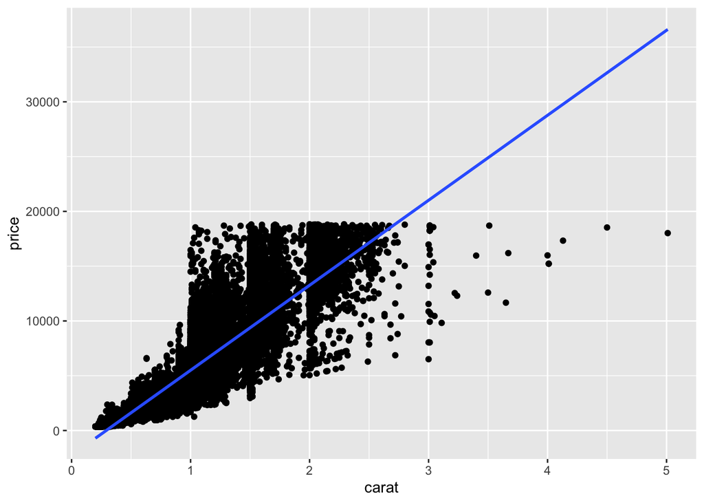

```r
# it will also help to visualize

ggplot(data = diamonds)+
  aes(x = carat,
      y = price)+
  geom_point()+
  geom_smooth(method = "lm")
```

### Part A

What is $\hat{\beta_1}$? Interpret it in the context of our regression.

$\hat{\beta_1}$, the estimated slope, is 7756.43. For every 1 carat, we expect the price of the diamond to increase by $7,756.43.

### Part B

Use `broom`’s `tidy()` command, and calculate a confidence interval by including `conf.int = T` inside `tidy()`. What is the 95% confidence interval for $\hat{\beta_1}$, and what does it mean? Save these endpoints as an object.

```r
library(broom)

reg_tidy<-reg %>% tidy(conf.int = T)

# look at tidy outcome
reg_tidy
```

| term | estimate | std.error | statistic | p.value | conf.low | conf.high |
| --- | --- | --- | --- | --- | --- | --- |
| (Intercept) | -2256.361 | 13.05535 | -172.8304 | 0 | -2281.949 | -2230.772 |
| carat | 7756.426 | 14.06658 | 551.4081 | 0 | 7728.855 | 7783.996 |

```r
# extract & save the confidence interval
CI_endpoints <- reg_tidy %>%
  filter(term == "carat") %>%
  select(conf.low, conf.high)

# look at it
CI_endpoints
```

| conf.low | conf.high |
| --- | --- |
| 7728.855 | 7783.996 |

We are 95% confident that in similarly constructed samples, the true effect of carat on price $(\beta_1)$ is between $7,728.86 and $7,784.00.

I am also going to extract and save our $\hat{\beta_1}$ estimate as an object, that we will use later with `infer`:

```r
# extract and save sample slope as object called beta_1_hat

beta_1_hat <- reg_tidy %>%
  filter(term == "carat") %>%
  select(estimate)

# confirm
beta_1_hat
```

| estimate |
| --- |
| 7756.426 |

## Question 3

Now let’s use `infer`. Install it if you don’t have it, then load it.

```r
# install.packages("infer")
library(infer)
```

### Part A

Let’s generate a confidence interval. First `specify()` the model relationship, then `generate()` `reps = 1000` repetitions of the sample using a `type = bootstrap`, then have it `calculate(stat = "slope")`.[^1] What does it show you?

```r
diamonds %>%
  specify(price ~ carat) %>%
  generate(reps = 1000,
           type = "bootstrap") %>%
  calculate(stat = "slope")
```

| replicate | stat |
| --- | --- |
| 1 | 7718.764 |
| 2 | 7728.067 |
| 3 | 7744.657 |
| 4 | 7726.734 |
| 5 | 7735.944 |
| 6 | 7803.907 |
| 7 | 7695.451 |
| 8 | 7763.051 |
| 9 | 7787.877 |
| 10 | 7797.414 |

[output cut: 990 more lines]

This produces 1,000 bootstrapped samples, and calculates the estimated regression slope $(\hat{\beta_1})$ for each sample.

### Part B

Continue the pipeline from part A, next have it `get_confidence_interval()`. Set `level = 0.95, type = "se"` and `point_estimate` equal to our estimated $\hat{\beta_1}$ from Question 2.

```r
diamonds %>%
  specify(price ~ carat) %>%
  generate(reps = 1000,
           type = "bootstrap") %>%
  calculate(stat = "slope") %>%
  get_confidence_interval(level = 0.95, #<<
                          type = "se", #<<
                          point_estimate = beta_1_hat) #<<
```

| lower_ci | upper_ci |
| --- | --- |
| 7707.357 | 7805.494 |

```r
# in the last part, you could type in our actual beta 1 hat, 7756.426;
# but I had saved it for easy use
```

### Part C

Now instead of `get_confidence_interval()`, pipe into `visualize()` to see the distribution. If you saved the confidence interval endpoints from part 1B, you can finally add `+shade_ci(endpoints = ...)` setting the argument equal to whatever you called your object containing the confidence interval.

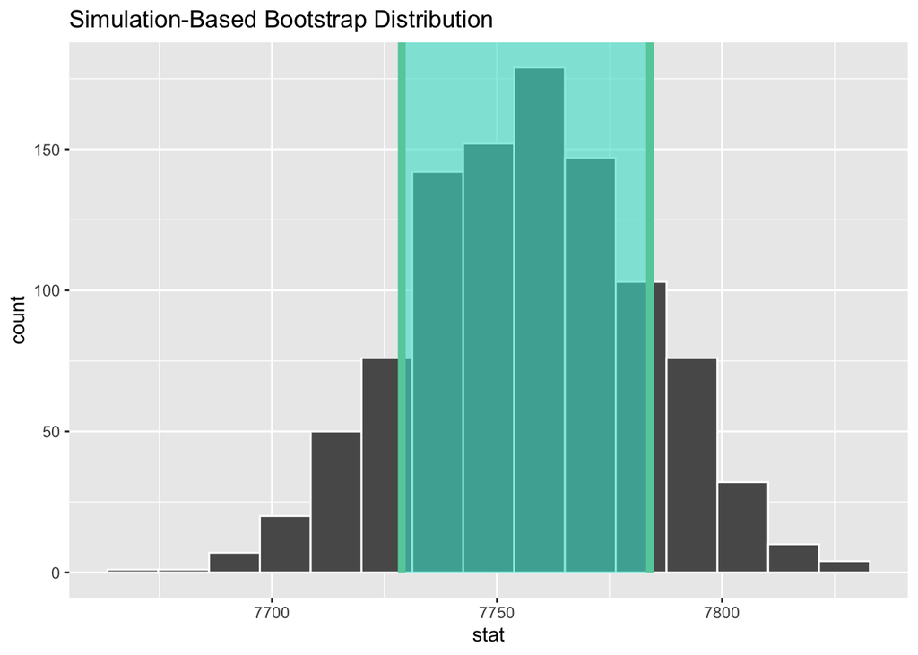

```r
diamonds %>%
  specify(price ~ carat) %>%
  generate(reps = 1000,
           type = "bootstrap") %>%
  calculate(stat = "slope") %>%
  visualize()+
  shade_ci(endpoints = CI_endpoints)
```

## Question 4

Now let’s test the following hypothesis:

$$\begin{align*}
H_0: \beta_1 &= 0\\
H_1: \beta_1 &\neq 0\\
\end{align*}$$

### Part A

What does the output of `summary` or of `tidy` from Question 2 tell you?

Reading the second row of estimates from the `lm summary` or `tidy` output of question 2, we saw that the `estimate` on `carat` $(\hat{\beta_1})$ was 7756.43, with a standard error of 14.07. This yields a test statistic value of 551.4, and a $p$-value of basically 0.

If you are wondering, the test-statistic was calculated, as described in the slides, as:

$$\begin{align*}
t & = \frac{\text{estimate} - \text{null hypothesis}}{\text{SE(estimate)}}\\
t & = \frac{7756.43 - 0}{14.07}\\
t &\approx 551.3 \\
\end{align*}$$

If the null hypothesis were true $(\beta_1=0)$, the probability that we get a test-statistic at least as extreme as 551.3 (essentially, 551 standard deviations away!!) is virtually 0. You can see this when we visualize using infer, below.

### Part B

Let’s now do this with `infer`. First `specify()` the model relationship, then `hypothesize(null = "independence")` to declare $H_0: \beta_1 = 0$, then `generate()` `reps = 1000` repetitions of the sample using a `type = permute`, then have it `calculate(stat = "slope")`. What does it show you?

```r
diamonds %>%
  specify(price ~ carat) %>%
  hypothesize(null = "independence") %>%
  generate(reps = 1000,
           type = "permute") %>%
  calculate(stat = "slope")
```

| replicate | stat |
| --- | --- |
| 1 | -22.29828971 |
| 2 | 18.85140255 |
| 3 | -27.79058671 |
| 4 | -25.69493552 |
| 5 | 15.39292847 |
| 6 | 28.30763621 |
| 7 | -51.26679480 |
| 8 | -28.26453282 |
| 9 | -28.98661881 |
| 10 | -51.44476110 |

[output cut: 990 more lines]

This produces 1,000 permuted samples, under the assumption that the true slope is 0 (the null hypothesis), and calculates the estimated regression slope $(\hat{\beta_1})$ for each sample.

### Part C

Continue the pipeline from part B, next have it `get_p_value()`. Inside this function, set `obs_stat` equal to our $\hat{\beta_1}$ we found, and set `direction = "both"` to run a two-sided test, since our alternative hypothesis is two-sided, $H_1: \beta_1 \neq 0$.

```r
diamonds %>%
  specify(price ~ carat) %>%
  hypothesize(null = "independence") %>%
  generate(reps = 1000,
           type = "permute") %>%
  calculate(stat = "slope") %>%
  get_p_value(obs_stat = beta_1_hat, #<<
              direction = "both") #<<
```

| p_value |
| --- |
| 0 |

```r
# again, instead of beta_1_hat you could type in 7756.426
```

### Part D

Instead of `get_p_value()`, pipe into `visualize(obs_stat = ... , direction = "both").` where `...` is our estimated $\hat{\beta_1}$.

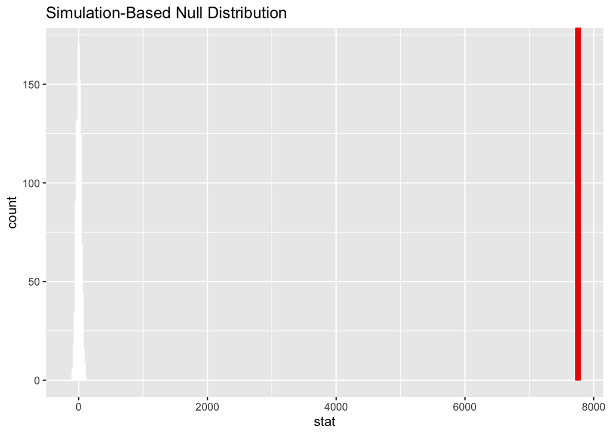

```r
diamonds %>%
  specify(price ~ carat) %>%
  hypothesize(null = "independence") %>%
  generate(reps = 1000,
           type = "permute") %>%
  calculate(stat = "slope") %>%
  visualize(obs_stat = beta_1_hat, #<<
                direction = "both") #<<
```

[^1]: Note this will take a few minutes, its doing a lot of calculations!